# Part I - Prosper Loan analysis

## Introduction

> This project explores a dataset containing peer-to-peer loan information of approximately 113,000 loans from Prosper Funding LLC.

## Preliminary Wrangling

```python
# import all packages and set plots to be embedded inline
import numpy as np
import pandas as pd
import matplotlib.pyplot as plt
import seaborn as sb

%matplotlib inline
```

```python
loan = pd.read_csv('prosperLoanData (1).csv')
```

```python
loan.shape
```

```
(113937, 81)
```

```python
pd.set_option('display.max_columns', 81)
```

```python
loan.head()
```

|  | ListingKey | ListingNumber | ListingCreationDate | CreditGrade | Term | LoanStatus | ClosedDate | BorrowerAPR | BorrowerRate | LenderYield | ... | LP_ServiceFees | LP_CollectionFees | LP_GrossPrincipalLoss | LP_NetPrincipalLoss | LP_NonPrincipalRecoverypayments | PercentFunded | Recommendations | InvestmentFromFriendsCount | InvestmentFromFriendsAmount | Investors |
| --- | --- | --- | --- | --- | --- | --- | --- | --- | --- | --- | --- | --- | --- | --- | --- | --- | --- | --- | --- | --- | --- |
| 0 | 1021339766868145413AB3B | 193129 | 2007-08-26 19:09:29.263000000 | C | 36 | Completed | 2009-08-14 00:00:00 | 0.16516 | 0.1580 | 0.1380 | ... | -133.18 | 0.0 | 0.0 | 0.0 | 0.0 | 1.0 | 0 | 0 | 0.0 | 258 |
| 1 | 10273602499503308B223C1 | 1209647 | 2014-02-27 08:28:07.900000000 | NaN | 36 | Current | NaN | 0.12016 | 0.0920 | 0.0820 | ... | 0.00 | 0.0 | 0.0 | 0.0 | 0.0 | 1.0 | 0 | 0 | 0.0 | 1 |
| 2 | 0EE9337825851032864889A | 81716 | 2007-01-05 15:00:47.090000000 | HR | 36 | Completed | 2009-12-17 00:00:00 | 0.28269 | 0.2750 | 0.2400 | ... | -24.20 | 0.0 | 0.0 | 0.0 | 0.0 | 1.0 | 0 | 0 | 0.0 | 41 |
| 3 | 0EF5356002482715299901A | 658116 | 2012-10-22 11:02:35.010000000 | NaN | 36 | Current | NaN | 0.12528 | 0.0974 | 0.0874 | ... | -108.01 | 0.0 | 0.0 | 0.0 | 0.0 | 1.0 | 0 | 0 | 0.0 | 158 |
| 4 | 0F023589499656230C5E3E2 | 909464 | 2013-09-14 18:38:39.097000000 | NaN | 36 | Current | NaN | 0.24614 | 0.2085 | 0.1985 | ... | -60.27 | 0.0 | 0.0 | 0.0 | 0.0 | 1.0 | 0 | 0 | 0.0 | 20 |

5 rows × 81 columns

```python
# create a list of 21 variables to be explored
cols = ['ListingNumber', 'ListingCreationDate', 'CreditGrade', 'Term', 'LoanStatus', 'BorrowerAPR', 'BorrowerRate', 'ProsperRating (Alpha)', 'ListingCategory (numeric)', 'IsBorrowerHomeowner','Occupation', 'EmploymentStatus', 'CurrentDelinquencies', 'AmountDelinquent', 'DebtToIncomeRatio', 'IncomeRange', 'IncomeVerifiable', 'StatedMonthlyIncome', 'LoanCurrentDaysDelinquent', 'LoanOriginalAmount', 'MonthlyLoanPayment']
```

```python
# subset the dataframe using the list earlier created
loan_sub = loan[cols]
loan_sub.head()
```

|  | ListingNumber | ListingCreationDate | CreditGrade | Term | LoanStatus | BorrowerAPR | BorrowerRate | ProsperRating (Alpha) | ListingCategory (numeric) | IsBorrowerHomeowner | ... | EmploymentStatus | CurrentDelinquencies | AmountDelinquent | DebtToIncomeRatio | IncomeRange | IncomeVerifiable | StatedMonthlyIncome | LoanCurrentDaysDelinquent | LoanOriginalAmount | MonthlyLoanPayment |
| --- | --- | --- | --- | --- | --- | --- | --- | --- | --- | --- | --- | --- | --- | --- | --- | --- | --- | --- | --- | --- | --- |
| 0 | 193129 | 2007-08-26 19:09:29.263000000 | C | 36 | Completed | 0.16516 | 0.1580 | NaN | 0 | True | ... | Self-employed | 2.0 | 472.0 | 0.17 | $25,000-49,999 | True | 3083.333333 | 0 | 9425 | 330.43 |
| 1 | 1209647 | 2014-02-27 08:28:07.900000000 | NaN | 36 | Current | 0.12016 | 0.0920 | A | 2 | False | ... | Employed | 0.0 | 0.0 | 0.18 | $50,000-74,999 | True | 6125.000000 | 0 | 10000 | 318.93 |
| 2 | 81716 | 2007-01-05 15:00:47.090000000 | HR | 36 | Completed | 0.28269 | 0.2750 | NaN | 0 | False | ... | Not available | 1.0 | NaN | 0.06 | Not displayed | True | 2083.333333 | 0 | 3001 | 123.32 |
| 3 | 658116 | 2012-10-22 11:02:35.010000000 | NaN | 36 | Current | 0.12528 | 0.0974 | A | 16 | True | ... | Employed | 4.0 | 10056.0 | 0.15 | $25,000-49,999 | True | 2875.000000 | 0 | 10000 | 321.45 |
| 4 | 909464 | 2013-09-14 18:38:39.097000000 | NaN | 36 | Current | 0.24614 | 0.2085 | D | 2 | True | ... | Employed | 0.0 | 0.0 | 0.26 | $100,000+ | True | 9583.333333 | 0 | 15000 | 563.97 |

5 rows × 21 columns

```python
print(loan_sub.shape)
print(loan_sub.dtypes)
```

```
(113937, 21)
ListingNumber                  int64
ListingCreationDate           object
CreditGrade                   object
Term                           int64
LoanStatus                    object
BorrowerAPR                  float64
BorrowerRate                 float64
ProsperRating (Alpha)         object
ListingCategory (numeric)      int64
IsBorrowerHomeowner             bool
Occupation                    object
EmploymentStatus              object
CurrentDelinquencies         float64
AmountDelinquent             float64
DebtToIncomeRatio            float64
IncomeRange                   object
IncomeVerifiable                bool
StatedMonthlyIncome          float64
LoanCurrentDaysDelinquent      int64
LoanOriginalAmount             int64
MonthlyLoanPayment           float64
dtype: object
```

```python
# Replace the na values in Credit Grade and ProsperRating with empty spaces so we can merge the columns into one
loan_sub['CreditGrade'].fillna('', inplace = True)
loan_sub['ProsperRating (Alpha)'].fillna('', inplace = True)
```

```python
# The two columns are merged into a combined credit grade as CreditGrade is for ratings before 2009 and ProsperRating is for ratings after 2009
loan_sub['Combined_credit_grade'] = loan_sub['CreditGrade'] + loan_sub['ProsperRating (Alpha)']
```

```python
# We now have a column that has credit ratings for listing before and after 2009
loan_sub.head()
```

|  | ListingNumber | ListingCreationDate | CreditGrade | Term | LoanStatus | BorrowerAPR | BorrowerRate | ProsperRating (Alpha) | ListingCategory (numeric) | IsBorrowerHomeowner | ... | CurrentDelinquencies | AmountDelinquent | DebtToIncomeRatio | IncomeRange | IncomeVerifiable | StatedMonthlyIncome | LoanCurrentDaysDelinquent | LoanOriginalAmount | MonthlyLoanPayment | Combined_credit_grade |
| --- | --- | --- | --- | --- | --- | --- | --- | --- | --- | --- | --- | --- | --- | --- | --- | --- | --- | --- | --- | --- | --- |
| 0 | 193129 | 2007-08-26 19:09:29.263000000 | C | 36 | Completed | 0.16516 | 0.1580 |  | 0 | True | ... | 2.0 | 472.0 | 0.17 | $25,000-49,999 | True | 3083.333333 | 0 | 9425 | 330.43 | C |
| 1 | 1209647 | 2014-02-27 08:28:07.900000000 |  | 36 | Current | 0.12016 | 0.0920 | A | 2 | False | ... | 0.0 | 0.0 | 0.18 | $50,000-74,999 | True | 6125.000000 | 0 | 10000 | 318.93 | A |
| 2 | 81716 | 2007-01-05 15:00:47.090000000 | HR | 36 | Completed | 0.28269 | 0.2750 |  | 0 | False | ... | 1.0 | NaN | 0.06 | Not displayed | True | 2083.333333 | 0 | 3001 | 123.32 | HR |
| 3 | 658116 | 2012-10-22 11:02:35.010000000 |  | 36 | Current | 0.12528 | 0.0974 | A | 16 | True | ... | 4.0 | 10056.0 | 0.15 | $25,000-49,999 | True | 2875.000000 | 0 | 10000 | 321.45 | A |
| 4 | 909464 | 2013-09-14 18:38:39.097000000 |  | 36 | Current | 0.24614 | 0.2085 | D | 2 | True | ... | 0.0 | 0.0 | 0.26 | $100,000+ | True | 9583.333333 | 0 | 15000 | 563.97 | D |

5 rows × 22 columns

```python
# our check shows there are no null values as the columns takes into account pre and post 2009
loan_sub.Combined_credit_grade.isnull().sum()
```

```
0
```

```python
# We can now drop the two columns as we have a column,Combined_credit_grade that combines the two values
drop_list = ['ProsperRating (Alpha)', 'CreditGrade']
```

```python
# drop the two columns
loan_sub.drop(drop_list, axis = 1, inplace = True)
```

```python
# Check shows that the columns have been dropped
loan_sub.head(10)
```

|  | ListingNumber | ListingCreationDate | Term | LoanStatus | BorrowerAPR | BorrowerRate | ListingCategory (numeric) | IsBorrowerHomeowner | Occupation | EmploymentStatus | CurrentDelinquencies | AmountDelinquent | DebtToIncomeRatio | IncomeRange | IncomeVerifiable | StatedMonthlyIncome | LoanCurrentDaysDelinquent | LoanOriginalAmount | MonthlyLoanPayment | Combined_credit_grade |
| --- | --- | --- | --- | --- | --- | --- | --- | --- | --- | --- | --- | --- | --- | --- | --- | --- | --- | --- | --- | --- |
| 0 | 193129 | 2007-08-26 19:09:29.263000000 | 36 | Completed | 0.16516 | 0.1580 | 0 | True | Other | Self-employed | 2.0 | 472.0 | 0.17 | $25,000-49,999 | True | 3083.333333 | 0 | 9425 | 330.43 | C |
| 1 | 1209647 | 2014-02-27 08:28:07.900000000 | 36 | Current | 0.12016 | 0.0920 | 2 | False | Professional | Employed | 0.0 | 0.0 | 0.18 | $50,000-74,999 | True | 6125.000000 | 0 | 10000 | 318.93 | A |
| 2 | 81716 | 2007-01-05 15:00:47.090000000 | 36 | Completed | 0.28269 | 0.2750 | 0 | False | Other | Not available | 1.0 | NaN | 0.06 | Not displayed | True | 2083.333333 | 0 | 3001 | 123.32 | HR |
| 3 | 658116 | 2012-10-22 11:02:35.010000000 | 36 | Current | 0.12528 | 0.0974 | 16 | True | Skilled Labor | Employed | 4.0 | 10056.0 | 0.15 | $25,000-49,999 | True | 2875.000000 | 0 | 10000 | 321.45 | A |
| 4 | 909464 | 2013-09-14 18:38:39.097000000 | 36 | Current | 0.24614 | 0.2085 | 2 | True | Executive | Employed | 0.0 | 0.0 | 0.26 | $100,000+ | True | 9583.333333 | 0 | 15000 | 563.97 | D |
| 5 | 1074836 | 2013-12-14 08:26:37.093000000 | 60 | Current | 0.15425 | 0.1314 | 1 | True | Professional | Employed | 0.0 | 0.0 | 0.36 | $100,000+ | True | 8333.333333 | 0 | 15000 | 342.37 | B |
| 6 | 750899 | 2013-04-12 09:52:56.147000000 | 36 | Current | 0.31032 | 0.2712 | 1 | False | Sales - Retail | Employed | 0.0 | 0.0 | 0.27 | $25,000-49,999 | True | 2083.333333 | 0 | 3000 | 122.67 | E |
| 7 | 768193 | 2013-05-05 06:49:27.493000000 | 36 | Current | 0.23939 | 0.2019 | 2 | False | Laborer | Employed | 0.0 | 0.0 | 0.24 | $25,000-49,999 | True | 3355.750000 | 0 | 10000 | 372.60 | C |
| 8 | 1023355 | 2013-12-02 10:43:39.117000000 | 36 | Current | 0.07620 | 0.0629 | 7 | True | Food Service | Employed | 0.0 | 0.0 | 0.25 | $25,000-49,999 | True | 3333.333333 | 0 | 10000 | 305.54 | AA |
| 9 | 1023355 | 2013-12-02 10:43:39.117000000 | 36 | Current | 0.07620 | 0.0629 | 7 | True | Food Service | Employed | 0.0 | 0.0 | 0.25 | $25,000-49,999 | True | 3333.333333 | 0 | 10000 | 305.54 | AA |

#### We convert ListingCategory column into a category variable as they are not numbers but shows category of loans.

The category of the listing that the borrower selected when posting their listing: 0 - Not Available, 1 - Debt Consolidation, 2 - Home Improvement, 3 - Business, 4 - Personal Loan, 5 - Student Use, 6 - Auto, 7- Other, 8 - Baby&Adoption, 9 - Boat, 10 - Cosmetic Procedure, 11 - Engagement Ring, 12 - Green Loans, 13 - Household Expenses, 14 - Large Purchases, 15 - Medical/Dental, 16 - Motorcycle, 17 - RV, 18 - Taxes, 19 - Vacation, 20 - Wedding Loans

```python
loan_sub['ListingCategory (numeric)'] = loan_sub['ListingCategory (numeric)'].astype('category')
```

```python
# there are values in the income range that are not range of numbers
loan_sub['IncomeRange'].value_counts()
```

```
$25,000-49,999    32192
$50,000-74,999    31050
$100,000+         17337
$75,000-99,999    16916
Not displayed      7741
$1-24,999          7274
Not employed        806
$0                  621
Name: IncomeRange, dtype: int64
```

```python
# use replace function in order to make not displayed and not employed columns as 0
loan_sub['IncomeRange'].replace('Not displayed', np.nan, inplace = True)
loan_sub['IncomeRange'].replace('Not employed', '$0', inplace = True)
```

```python
# check to see that the values have been changed to $0
loan_sub['IncomeRange'].value_counts()
```

[output not shown]

```python
# convert Combined_gredit_grade into ordered categorical types
ordinal_var_dict = {'Combined_credit_grade': ['AA','A','B','C','D','E','HR'],
                    'IncomeRange': ['$0', '$1-24,999', '$25,000-49,999', '$50,000-74,999', '$75,000-99,999', '$100,000+']}


for var in ordinal_var_dict:
    ordered_var = pd.api.types.CategoricalDtype(ordered = True,
                                                categories = ordinal_var_dict[var])
    loan_sub[var] = loan_sub[var].astype(ordered_var)
```

### What is the structure of your dataset?

> The dataset was extracted from the original dataset that contained 113,937 rows and 81 columns. Some key variables which are useful to our insights were identified and analysis carried out.

> I was able to merge two columns to a single column to show credit grades pre 2009 and post 2009 and ordered them into categorical typle from the best to the worst ratings

> Income range was cleaned to removed the Not displayed and not employed to strictryly numbers and include income range strictly from 0 - 100k+

### What is/are the main feature(s) of interest in your dataset?

> I am interested in finding out features and relationship between different variables across the dataset and also to find out the variable that is the best predictor of deliquencies

### What features in the dataset do you think will help support your investigation into your feature(s) of interest?

> I think features such as low income range, low credit score, high debt to income ratio among others will affect the chances of a loan being deliquent.

## Univariate Exploration

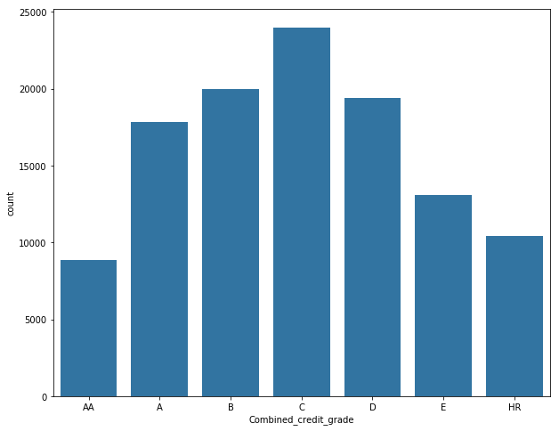

```python
plt.figure(figsize = [10,8])
base_color = sb.color_palette()[0]
sb.countplot(data = loan_sub, x = 'Combined_credit_grade', color = base_color)
```

The distribution is unimodal and skewed to the right. Point to note is that there are more borrowers who are termed high risk than people with excellent credit grade

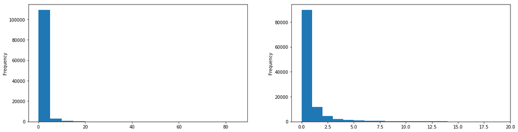

```python
# Lets look at the distribution of no of deliquencies
plt.figure(figsize = [20,5])
plt.subplot(1,2,1)
bins = np.arange(0, loan_sub['CurrentDelinquencies'].max()+5, 5 )
loan_sub['CurrentDelinquencies'].plot(kind = 'hist', bins = bins)
#Lets zoom in from 0 to 20 as it seems most of the action is concentrated there
plt.subplot(1,2,2)
bins = np.arange(0, loan_sub['CurrentDelinquencies'].max()+1, 1 )
loan_sub['CurrentDelinquencies'].plot(kind = 'hist', bins = bins)
plt.xlim(-1, 20);
```

The distribution is highly skewed to the right.

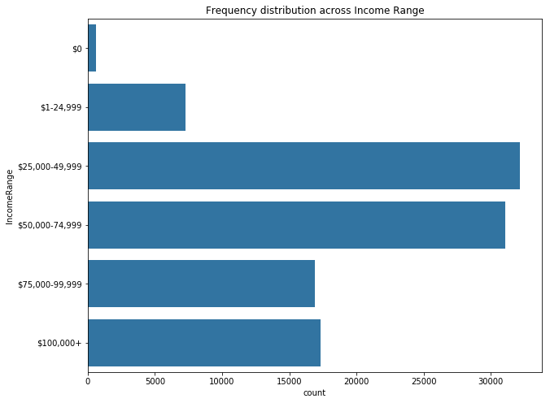

```python
plt.figure(figsize = [10,8])
base_color = sb.color_palette()[0]
sb.countplot(data = loan_sub, y = 'IncomeRange', color = base_color)
plt.title('Frequency distribution across Income Range');
```

The income distribution shows that most of the borrowers have an income range between 25,000 and 75,000

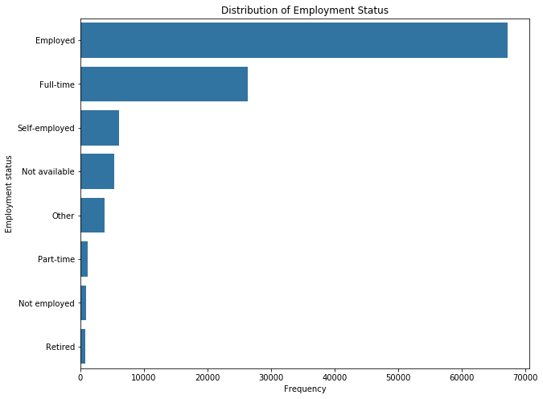

```python
# Creating an horizontal barchart to show the distribution of the borrowers across the EmploymentStatus categories
plt.figure(figsize = [10, 8])
base_color = sb.color_palette()[0]
order = loan_sub['EmploymentStatus'].value_counts().index
sb.countplot(data= loan_sub, y= 'EmploymentStatus', color = base_color, order = order)
plt.title("Distribution of Employment Status")
plt.xlabel("Frequency")
plt.ylabel("Employment status");
```

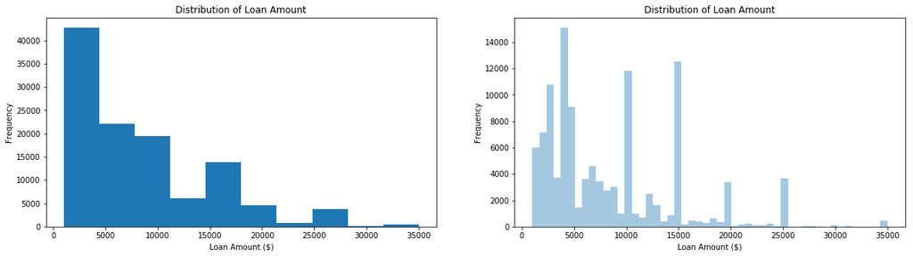

```python
plt.figure(figsize = [20,5])
plt.subplot(1,2,1)
plt.hist(data = loan_sub, x = 'LoanOriginalAmount')
plt.xlabel('Loan Amount ($)')
plt.ylabel('Frequency')
plt.title('Distribution of Loan Amount')

plt.subplot(1,2,2)
sb.distplot(loan_sub['LoanOriginalAmount'], kde = False, color = base_color)
plt.ylabel('Frequency')
plt.xlabel('Loan Amount ($)')
plt.title('Distribution of Loan Amount');
```

It is evident from the distribution that most of the loans taken is rightly skewed. Using the distplot function with more bins showed that the loans are usually round figures as evident in spikes on 5,000 10,000 , 15,000 and so on

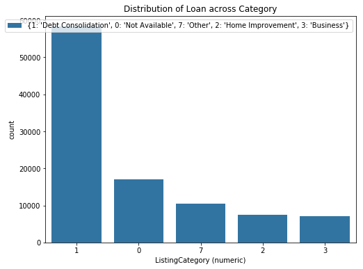

```python
base_color = sb.color_palette()[0]
plt.figure(figsize = [8, 6])
order = loan_sub['ListingCategory (numeric)'].value_counts().iloc[:5].index
sb.countplot(data = loan_sub, x = 'ListingCategory (numeric)', order = order, color = base_color)
plt.legend(labels = [{1:'Debt Consolidation',0: 'Not Available', 7: 'Other', 2: 'Home Improvement', 3: 'Business'}])
plt.title('Distribution of Loan across Category');
```

```python
loan_sub['ListingCategory (numeric)'].value_counts()
```

```
1     58308
0     16965
7     10494
2      7433
3      7189
6      2572
4      2395
13     1996
15     1522
18      885
14      876
20      771
19      768
5       756
16      304
11      217
8       199
10       91
9        85
12       59
17       52
Name: ListingCategory (numeric), dtype: int64
```

This plot shows that most of the loans are used for Debt consolidations. Other categories in the top 5 shows Home Improvement and Business Loans are also common.

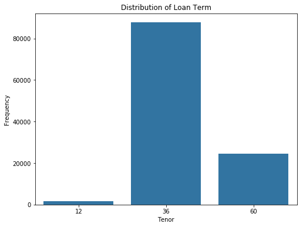

```python
# plotting a chart to show the frequency of distribution by Term
plt.figure(figsize = [8,6])
color_pal = sb.color_palette()[0]
sb.countplot(data= loan_sub, x= 'Term', color = color_pal)
plt.title("Distribution of Loan Term")
plt.xlabel("Tenor")
plt.ylabel("Frequency");
```

Most of the loans are long term loans with majority of them being for 36 months

> **Rubric Tip**: Visualizations should depict the data appropriately so that the plots are easily interpretable. You should choose an appropriate plot type, data encodings, and formatting as needed. The formatting may include setting/adding the title, labels, legend, and comments. Also, do not overplot or incorrectly plot ordinal data.

### Discuss the distribution(s) of your variable(s) of interest. Were there any unusual points? Did you need to perform any transformations?

> I discovered that most of the loans taken were for debt consolidation at around the typical interest rate. I also found out that most of the loans were long term loans with the most common term being for 36 months.

I also looked at the Income range distribution which mostly range from ($)25,000-74,999.

### Of the features you investigated, were there any unusual distributions? Did you perform any operations on the data to tidy, adjust, or change the form of the data? If so, why did you do this?

> I had to change some variables into ordered categorical variables. I also combined credit grades into one single column merging the two columns of credit grades pre and post 2009 to form a unifying credit grade.

## Bivariate Exploration

> In this section, investigate relationships between pairs of variables in your data. Make sure the variables that you cover here have been introduced in some fashion in the previous section (univariate exploration).

```python
numeric_vars = [ 'BorrowerAPR', 'BorrowerRate','CurrentDelinquencies', 'AmountDelinquent','DebtToIncomeRatio', 'LoanOriginalAmount']
```

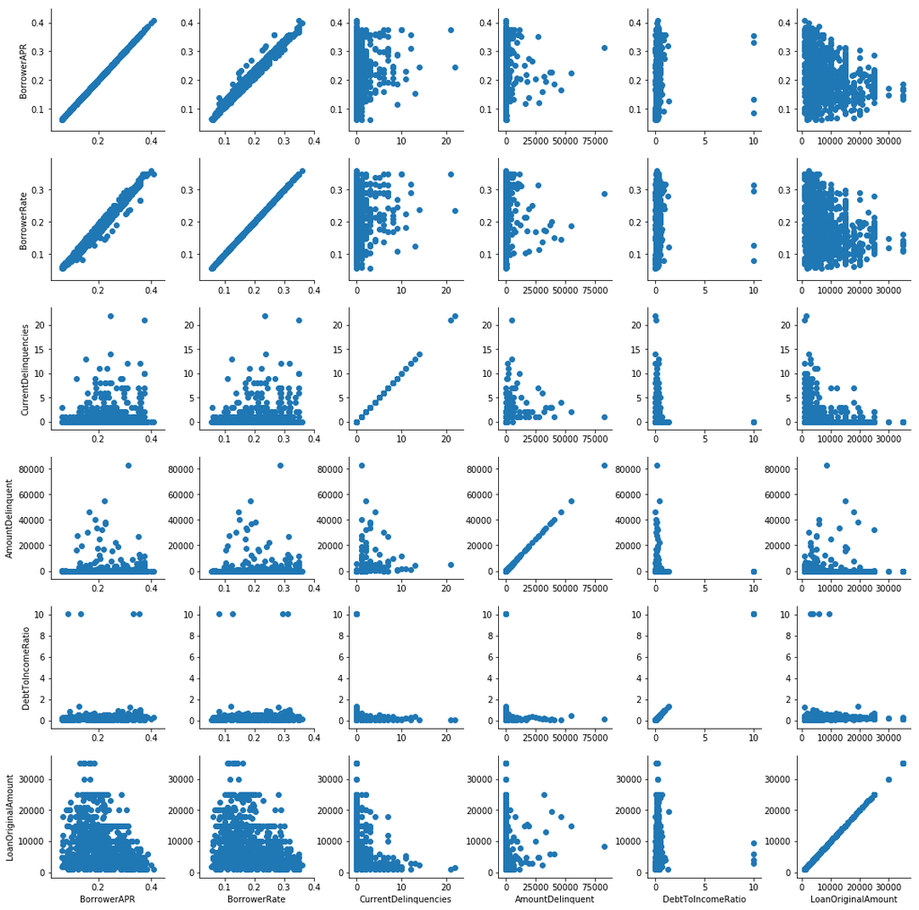

```python
# Plotting a plot matrix to investigate the relationship between the variables
loan_sub_samp = loan_sub.sample(n=1000, replace = False)

g = sb.PairGrid(data = loan_sub_samp, vars = numeric_vars)
g.map(plt.scatter);
```

It is worth noting that most of our numeric variables seem to not have much correlation as suspected before the analysis.

The only visible positive correlation are betweeen Borrower Rate and Borrower APR which are almost the same thing with the exception of the fees

```
Text(0.5,0.98,'Çombined Credit Grade against Amount Deliquent')
```

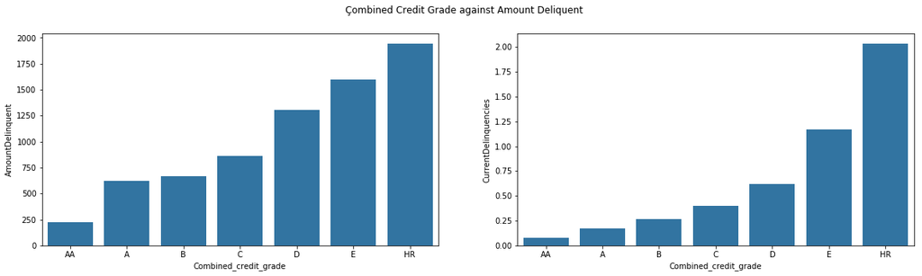

```python
plt.figure(figsize = [20,5])
plt.subplot(1,2,1)
base_color = sb.color_palette()[0]
sb.barplot(data = loan_sub, x = 'Combined_credit_grade', y = 'AmountDelinquent', color = base_color, ci = 0)

plt.subplot(1,2,2)
base_color = sb.color_palette()[0]
sb.barplot(data = loan_sub, x = 'Combined_credit_grade', y = 'CurrentDelinquencies', color = base_color, ci = 0)
plt.suptitle('Çombined Credit Grade against Amount Deliquent')
```

Bar chart shows that Deliquency increases across the credit grades from Excellent credit score to high risk in terms of count and amount

```
Text(0.5,1,'Income range against Deliquency')
```

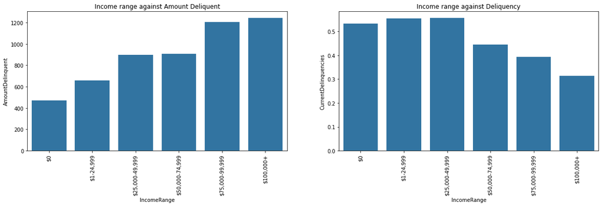

```python
plt.figure(figsize = [20,5])
plt.subplot(1,2,1)
base_color = sb.color_palette()[0]
sb.barplot(data = loan_sub, x = 'IncomeRange', y = 'AmountDelinquent', ci = 0, color = base_color)
plt.xticks(rotation=90);
plt.title('Income range against Amount Deliquent')

plt.subplot(1,2,2)
sb.barplot(data = loan_sub, x = 'IncomeRange', y = 'CurrentDelinquencies', ci = 0, color = base_color)
plt.xticks(rotation=90)
plt.title('Income range against Deliquency')
```

There seem to be a relationshipbetween high income range and amount of delinquent loans. However, for the no of current deliquencies, borrowers in the lower end of income tend to have more delinquencies than people in the high income range.

This means despite the fact that low income earners are more likely to have delinquent facilities compared to their high income counterparts, the volume of the amount of the high earners is bigger.

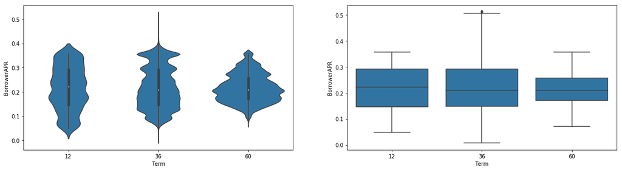

```python
base_color = sb.color_palette()[0]
plt.figure(figsize = [20,5])
plt.subplot(1,2,1)
sb.violinplot(data = loan_sub, x = 'Term', y = 'BorrowerAPR', color = base_color)

plt.subplot(1,2,2)
sb.boxplot(data = loan_sub, x = 'Term', y = 'BorrowerAPR', color = base_color)
```

The violin plots and box plot shows that loans with tenor of 12 and 36 seem to start at lower rates even though the maximum APR is almost the same except for some outliers in the 36 term loans.

```
Text(0.5,1,'Listing Category against Amount Delinquent')
```

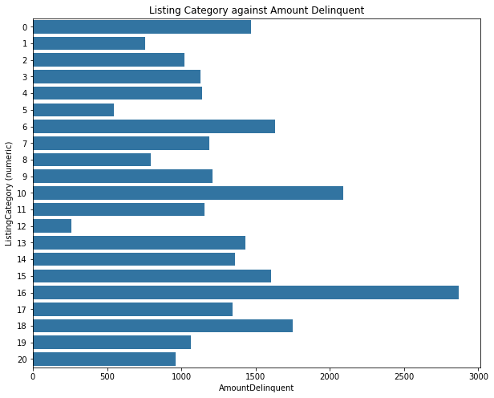

```python
plt.figure(figsize = [10,8])
base_color = sb.color_palette()[0]
sb.barplot(data = loan_sub, x = 'AmountDelinquent', y = 'ListingCategory (numeric)', ci = 0, color = base_color)
plt.title('Listing Category against Amount Delinquent')
```

The category of the listing that the borrower selected when posting their listing: 0 - Not Available, 1 - Debt Consolidation, 2 - Home Improvement, 3 - Business, 4 - Personal Loan, 5 - Student Use, 6 - Auto, 7- Other, 8 - Baby&Adoption, 9 - Boat, 10 - Cosmetic Procedure, 11 - Engagement Ring, 12 - Green Loans, 13 - Household Expenses, 14 - Large Purchases, 15 - Medical/Dental, 16 - Motorcycle, 17 - RV, 18 - Taxes, 19 - Vacation, 20 - Wedding Loans

This chart shows that the categories for the highest amount of deliquent loans are mostly facilities used on things like Motorcycles, Cosmetic Procedure, Taxes, Auto (Consumption spendings). This means that loans spent on consumption usually lead to delinquency

```
Text(0.5,1,'Loan Amount vs Borrower APR')
```

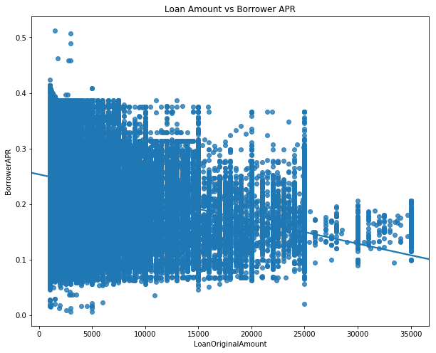

```python
plt.figure(figsize = [10,8])
sb.regplot(data = loan_sub, x = 'LoanOriginalAmount', y = 'BorrowerAPR')
plt.title('Loan Amount vs Borrower APR')
```

BorrowerAPR and Loan Amount are negatively correlated meaning the higher the Loan amount the lower the rates at which the loan is given.

This is makes a lot of seanse as the higher the loans go, the more borrowers are able to negotiate at lower rates

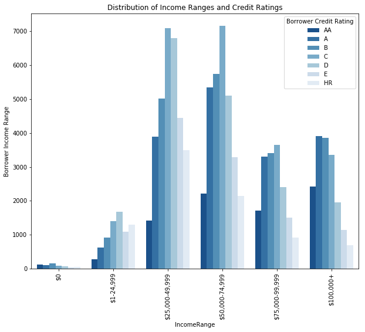

```python
plt.figure(figsize = [10,8])

ax = sb.countplot(data = loan_sub, x = 'IncomeRange', hue = 'Combined_credit_grade',
                   palette = 'Blues_r')

ax.legend(title = 'Borrower Credit Rating')
plt.xticks(rotation = 90)
plt.title('Distribution of Income Ranges and Credit Ratings')
plt.ylabel('Borrower Income Range');
```

From this clustered bar chart, we can see the trend of higher incomes correlate to a higher credit rating qualifying the borrower for the best (lowest) interest rates which confirms our earlier chart on APR and Loan Amount

Having an income of $75k+ doesn't automatically guarantee the best credit ratings.

Conversely, it also appears that in the $0 income range, there are a high amount of "AA" loans relative to the \$1-25k income range. This is very interesting as I do not understand how we can have AA loans for borrowers that make no income

### Talk about some of the relationships you observed in this part of the investigation. How did the feature(s) of interest vary with other features in the dataset?

As for Income range, we discovered that the amount of deliquency was higher with the higher income earners while the count of deliquency was higher with the low income earners

## Multivariate Exploration

> Create plots of three or more variables to investigate your data even further. Make sure that your investigations are justified, and follow from your work in the previous sections.

[figure not shown]

```python
g = sb.FacetGrid(data = loan_sub, col = 'IncomeRange', row = 'Term', margin_titles = True)
g.map(sb.regplot, 'LoanOriginalAmount', 'BorrowerAPR');
```

APR tends to increase across the income ranges for the short term loans while for the other terms, the distribution barely changes

The plot further reinforces the point that people with high income tends to get better(lower rate) than people on the lower end of the scale regardless of the amount as evident in the first matrix compared to the others

Depending on the income range or term, there seems to be some sort of negative correlation between APR and Loan amount. This means, the higher the loan amount, the lower the APR and vice versa

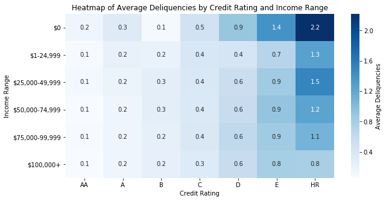

```python
# creating a heat map that shows the average count of deliquencies across Credit Rating and Income Range
plt.figure(figsize = [10,5])

cat_mean = loan_sub.groupby(['Combined_credit_grade', 'IncomeRange']).mean()['CurrentDelinquencies']
cat_mean = cat_mean.reset_index(name = 'Average Delinquencies')
cat_mean = cat_mean.pivot(index = 'IncomeRange', columns = 'Combined_credit_grade', values = 'Average Delinquencies')

sb.heatmap(cat_mean, annot = True, fmt = '.1f', cmap = "Blues", cbar_kws = {'label' : 'Average Deliquencies'})
plt.xlabel('Credit Rating')
plt.ylabel('Income Range')
plt.title('Heatmap of Average Deliquencies by Credit Rating and Income Range');
```

Income range does not seem to matter with no of deliquencies except for borrowers with bad credit ratings.

This shows us that a better predictor of deliquencies is using credit grade rather than the relationship between the numeric variables.

> I observed from this part of the investigation that the best predictor of deliquencies is Credit rating and not the income that is earned by the borrowers. This lends credence to the importance of good ratings in lending

## Conclusions

From the analysis, I was able to find out that:

1. Most lenders fall between the income range of 25k - 75k with the highest distribution of lenders being borrowers with C credit rating
2. Majorities of the loan taken out were for debt consolidation, Home improvement and business loans with the most common term of loan being for 36 months
3. There seem to be flexibility in the short term loans compared to the medium and long term loans.
4. Loans taken to fund consumption are more likely to go bad than the other type of loans.
5. Good credit rating is a better predictor of deliquencies than Income range and other numerical variables.